# Project_6

**DESCRIPTION**  
Context  
AllLife Bank wants to focus on its credit card customer base in the next financial year. They have been advised by their marketing research team, that the penetration in the market can be improved. Based on this input, the Marketing team proposes to run personalized campaigns to target new customers as well as upsell to existing customers. Another insight from the market research was that the customers perceive the support services of the back poorly. Based on this, the Operations team wants to upgrade the service delivery model, to ensure that customer queries are resolved faster. Head of Marketing and Head of Delivery both decide to reach out to the Data Science team for help.

Objective  
To identify different segments in the existing customer, based on their spending patterns as well as past interaction with the bank, using clustering algorithms, and provide recommendations to the bank on how to better market to and service these customers.

Data Description  
The data provided is of various customers of a bank and their financial attributes like credit limit, the total number of credit cards the customer has, and different channels through which customers have contacted the bank for any queries (including visiting the bank, online and through a call center).

Data Dictionary

Sl_No: Primary key of the records  
Customer Key: Customer identification number  
Average Credit Limit: Average credit limit of each customer for all credit cards  
Total credit cards: Total number of credit cards possessed by the customer  
Total visits bank: Total number of visits that customer made (yearly) personally to the bank  
Total visits online: Total number of visits or online logins made by the customer (yearly)  
Total calls made: Total number of calls made by the customer to the bank or its customer service department (yearly)

```python
# this will help in making the Python code more structured automatically (good coding practice)
%load_ext nb_black

# Libraries to help with reading and manipulating data
import numpy as np
import pandas as pd

# Libraries to help with data visualization
import matplotlib.pyplot as plt
import seaborn as sns

# Removes the limit for the number of displayed columns
pd.set_option("display.max_columns", None)
# Sets the limit for the number of displayed rows
pd.set_option("display.max_rows", 200)

# to scale the data using z-score
from sklearn.preprocessing import StandardScaler

# to compute distances
from scipy.spatial.distance import pdist

# to perform hierarchical clustering, compute cophenetic correlation, and create dendrograms
from sklearn.cluster import AgglomerativeClustering
from scipy.cluster.hierarchy import dendrogram, linkage, cophenet

# to perform PCA
from sklearn.decomposition import PCA

# this will help in making the Python code more structured automatically (good coding practice)

# to compute distances
from scipy.spatial.distance import cdist

# to perform k-means clustering and compute silhouette scores
from sklearn.cluster import KMeans
from sklearn.metrics import silhouette_score

# to visualize the elbow curve and silhouette scores
from yellowbrick.cluster import KElbowVisualizer, SilhouetteVisualizer
```

```python
data = pd.read_excel("CreditData.xlsx")
```

```python
data.shape
```

```
(660, 7)
```

```python
data.sample(n=10, random_state=1)
```

|  | Sl_No | Customer Key | Avg_Credit_Limit | Total_Credit_Cards | Total_visits_bank | Total_visits_online | Total_calls_made |
| --- | --- | --- | --- | --- | --- | --- | --- |
| 547 | 548 | 38125 | 26000 | 4 | 5 | 2 | 4 |
| 353 | 354 | 94437 | 9000 | 5 | 4 | 1 | 3 |
| 499 | 500 | 65825 | 68000 | 6 | 4 | 2 | 2 |
| 173 | 174 | 38410 | 9000 | 2 | 1 | 5 | 8 |
| 241 | 242 | 81878 | 10000 | 4 | 5 | 1 | 3 |
| 341 | 342 | 70779 | 18000 | 4 | 3 | 2 | 0 |
| 647 | 648 | 79953 | 183000 | 9 | 0 | 9 | 2 |
| 218 | 219 | 28208 | 19000 | 3 | 1 | 5 | 7 |
| 120 | 121 | 16577 | 10000 | 4 | 2 | 4 | 6 |
| 134 | 135 | 31256 | 13000 | 4 | 1 | 5 | 7 |

```python
df = data.copy()
```

```python
df.info()
```

```
<class 'pandas.core.frame.DataFrame'>
RangeIndex: 660 entries, 0 to 659
Data columns (total 7 columns):
 #   Column               Non-Null Count  Dtype
---  ------               --------------  -----
 0   Sl_No                660 non-null    int64
 1   Customer Key         660 non-null    int64
 2   Avg_Credit_Limit     660 non-null    int64
 3   Total_Credit_Cards   660 non-null    int64
 4   Total_visits_bank    660 non-null    int64
 5   Total_visits_online  660 non-null    int64
 6   Total_calls_made     660 non-null    int64
dtypes: int64(7)
memory usage: 36.2 KB
```

**Observations**  
All types are int64

```python
df.describe(include="all").T
```

|  | count | mean | std | min | 25% | 50% | 75% | max |
| --- | --- | --- | --- | --- | --- | --- | --- | --- |
| Sl_No | 660.0 | 330.500000 | 190.669872 | 1.0 | 165.75 | 330.5 | 495.25 | 660.0 |
| Customer Key | 660.0 | 55141.443939 | 25627.772200 | 11265.0 | 33825.25 | 53874.5 | 77202.50 | 99843.0 |
| Avg_Credit_Limit | 660.0 | 34574.242424 | 37625.487804 | 3000.0 | 10000.00 | 18000.0 | 48000.00 | 200000.0 |
| Total_Credit_Cards | 660.0 | 4.706061 | 2.167835 | 1.0 | 3.00 | 5.0 | 6.00 | 10.0 |
| Total_visits_bank | 660.0 | 2.403030 | 1.631813 | 0.0 | 1.00 | 2.0 | 4.00 | 5.0 |
| Total_visits_online | 660.0 | 2.606061 | 2.935724 | 0.0 | 1.00 | 2.0 | 4.00 | 15.0 |
| Total_calls_made | 660.0 | 3.583333 | 2.865317 | 0.0 | 1.00 | 3.0 | 5.00 | 10.0 |

```python
# Let's see unique values

df = df.drop(["Sl_No"], axis=1)
cols = df.columns

for col in cols:
    print("Unique values in the column '{}' are \n\n".format(col), df[col].unique())
    print("-" * 75)
```

```
Unique values in the column 'Customer Key' are

 [87073 38414 17341 40496 47437 58634 48370 37376 82490 44770 52741 52326
 92503 25084 68517 55196 62617 96463 39137 14309 29794 87241 30507 61061
 24001 68067 65034 14854 81130 29112 13999 32550 82164 61517 28254 30888
 46388 74126 52142 37659 83132 20119 52363 50769 68502 99026 83326 62040
 37252 74625 51182 60301 96386 43886 78503 68419 32828 17937 71632 81566
 29759 36929 70248 91673 61355 60403 85868 76205 66524 69214 21976 35149
 27120 18821 33187 93482 90168 71881 59656 12026 99589 38970 57990 39447
 79694 79403 47296 37559 38165 49198 18007 59619 37016 91099 74704 25742
 11937 52736 88338 18916 92501 96213 26599 73007 97935 26089 14946 74795
 73435 41634 84069 83244 87291 18086 33369 15310 98499 35256 89007 93997
 16577 25440 81116 63663 69811 36111 39454 70199 11602 49697 28701 61627
 34103 14248 31256 45583 52750 95507 23743 53410 53898 66200 58389 61347
 59151 37802 60475 95489 77758 23768 87471 85707 97951 54785 97011 35103
```

[output cut: 73 more lines]

**Observations**  
All the numbers seem normal. There may be no reason to impute missing data or deal with outliers. Let's check the average credit limit and see if there are outliers there with a boxplot.

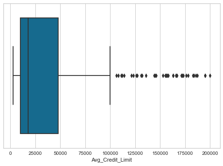

```python
sns.boxplot(x=df["Avg_Credit_Limit"])
```

Although there are outliers, I don't think I need to deal with them because the data is important. There is no reason for this data to be in the thousands though, so I'm going to reduce it to smaller integers.

```python
df["Avg_Credit_Limit"] /= 1000
df["Avg_Credit_Limit"]
```

```
0      100.0
1       50.0
2       50.0
3       30.0
4      100.0
       ...
655     99.0
656     84.0
657    145.0
658    172.0
659    167.0
Name: Avg_Credit_Limit, Length: 660, dtype: float64
```

```python
df[df.duplicated(keep=False)]
df = df.drop(
    [
        17,
        29,
        56,
        162,
        175,
        215,
        250,
        252,
        257,
        295,
        310,
        320,
        324,
        334,
        361,
        378,
        385,
        395,
        425,
        455,
        464,
        497,
    ]
)
```

Duplicated rows are now removed.

```python
df.isnull().sum()
```

```
Customer Key           0
Avg_Credit_Limit       0
Total_Credit_Cards     0
Total_visits_bank      0
Total_visits_online    0
Total_calls_made       0
dtype: int64
```

No missing values means no imputation.

```python
# function to plot a boxplot and a histogram along the same scale.


def histogram_boxplot(data, feature, figsize=(12, 7), kde=False, bins=None):
    """
    Boxplot and histogram combined

    data: dataframe
    feature: dataframe column
    figsize: size of figure (default (12,7))
    kde: whether to the show density curve (default False)
    bins: number of bins for histogram (default None)
    """
    f2, (ax_box2, ax_hist2) = plt.subplots(
        nrows=2,  # Number of rows of the subplot grid= 2
        sharex=True,  # x-axis will be shared among all subplots
        gridspec_kw={"height_ratios": (0.25, 0.75)},
        figsize=figsize,
    )  # creating the 2 subplots
    sns.boxplot(
        data=data, x=feature, ax=ax_box2, showmeans=True, color="violet"
    )  # boxplot will be created and a star will indicate the mean value of the column
    sns.histplot(
        data=data, x=feature, kde=kde, ax=ax_hist2, bins=bins, palette="winter"
    ) if bins else sns.histplot(
        data=data, x=feature, kde=kde, ax=ax_hist2, discrete=True
    )  # For histogram
    ax_hist2.axvline(
        data[feature].mean(), color="green", linestyle="--"
    )  # Add mean to the histogram
    ax_hist2.axvline(
        data[feature].median(), color="black", linestyle="-"
    )  # Add median to the histogram
```

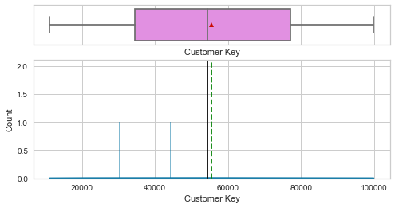

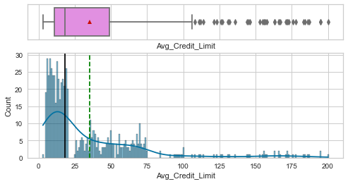

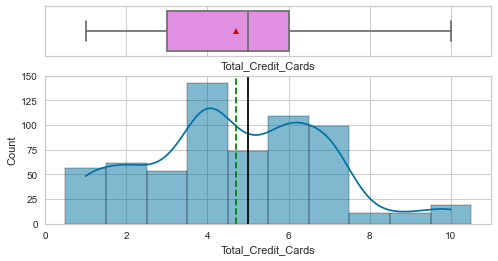

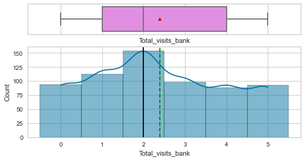

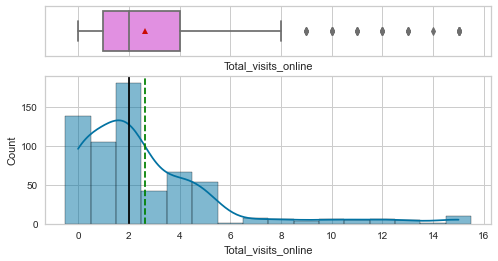

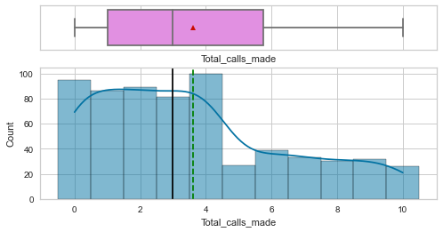

```python
# selecting numerical columns
num_col = df.select_dtypes(include=np.number).columns.tolist()

for item in num_col:
    histogram_boxplot(df, item, kde=True, figsize=(8, 4))
```

**Univariate Analysis**  
The average credit limit and total visits online are very skewed.  
There aren't a lot of people with more than 7 credit cards.

[figure not shown]

```python
sns.pairplot(df)
```

**Bivariate Analysis**  
Honestly too much is going on in these graphs for me to be able to see any kind of correlation in any graph. Most simply look evenly distributed.

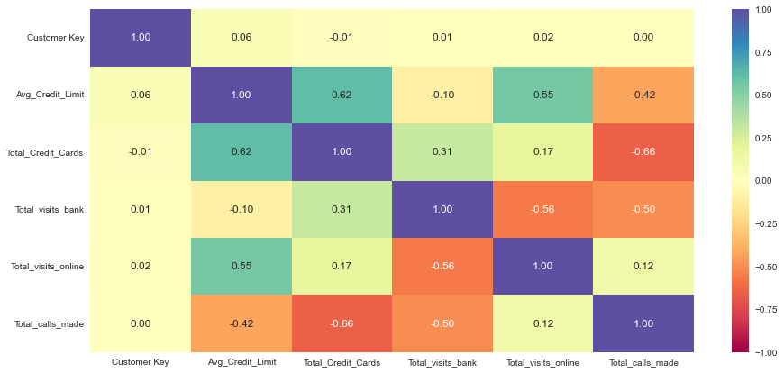

```python
num_cols = df.select_dtypes(include=np.number).columns.tolist()

plt.figure(figsize=(15, 7))
sns.heatmap(
    df[num_cols].corr(), annot=True, vmin=-1, vmax=1, fmt=".2f", cmap="Spectral"
)
plt.show()
```

I will be discussing the variables with more than a .5 or -.5 rlation with each other and try to explain why.  
**Correlations**  
Total_Credit_cards and Avg_Credit_Limit: It makes sense that the more credit cards someone has the higher their credit limit is.  
Avg_Credit_Limit and Total_Visits_Online: I'm honestly not sure how these values are related but it's most likely due to various subvariables such as credit card usage.  
Total_Visits_Bank and Total_Visits_Online: It makes sense that people who visit online have no need to go to the bank.  
Total_Calls_Made and Total_Credit_Cards: I assume that this is because you need to make a call to get a credit card.

```python
sc = StandardScaler()
subset_scaled_df = pd.DataFrame(
    sc.fit_transform(df),
    columns=df.columns,
)
subset_scaled_df
```

|  | Customer Key | Avg_Credit_Limit | Total_Credit_Cards | Total_visits_bank | Total_visits_online | Total_calls_made |
| --- | --- | --- | --- | --- | --- | --- |
| 0 | 1.239423 | 1.706569 | -1.244899 | -0.860795 | -0.553430 | -1.245302 |
| 1 | -0.667121 | 0.389918 | -0.785798 | -1.479249 | 2.478817 | 1.870395 |
| 2 | -1.492798 | 0.389918 | 1.050609 | -0.860795 | 0.120403 | 0.139452 |
| 3 | -0.585545 | -0.136742 | 0.132405 | -0.860795 | -0.553430 | 0.139452 |
| 4 | -0.313584 | 1.706569 | 0.591507 | -1.479249 | 3.152650 | -0.206736 |
| ... | ... | ... | ... | ... | ... | ... |
| 633 | -0.169748 | 1.680236 | 2.427914 | -0.860795 | 2.478817 | -1.245302 |
| 634 | 0.207337 | 1.285241 | 2.427914 | -0.860795 | 3.489566 | -0.552925 |
| 635 | -0.062939 | 2.891555 | 1.509710 | -0.860795 | 2.141901 | -0.899114 |
| 636 | 0.987955 | 3.602546 | 2.427914 | -0.860795 | 4.163399 | -1.245302 |
| 637 | 0.968168 | 3.470881 | 1.968812 | -1.479249 | 3.152650 | -0.552925 |

638 rows × 6 columns

```python
# list of distance metrics
distance_metrics = ["euclidean", "chebyshev", "mahalanobis", "cityblock"]

# list of linkage methods
linkage_methods = ["single", "complete", "average", "weighted"]

high_cophenet_corr = 0
high_dm_lm = [0, 0]

for dm in distance_metrics:
    for lm in linkage_methods:
        Z = linkage(subset_scaled_df, metric=dm, method=lm)
        c, coph_dists = cophenet(Z, pdist(subset_scaled_df))
        print(
            "Cophenetic correlation for {} distance and {} linkage is {}.".format(
                dm.capitalize(), lm, c
            )
        )
        if high_cophenet_corr < c:
            high_cophenet_corr = c
            high_dm_lm[0] = dm
            high_dm_lm[1] = lm
```

```
Cophenetic correlation for Euclidean distance and single linkage is 0.7145328844221719.
Cophenetic correlation for Euclidean distance and complete linkage is 0.836104463344554.
Cophenetic correlation for Euclidean distance and average linkage is 0.8666394295227281.
Cophenetic correlation for Euclidean distance and weighted linkage is 0.8548246918431006.
Cophenetic correlation for Chebyshev distance and single linkage is 0.699158883035983.
Cophenetic correlation for Chebyshev distance and complete linkage is 0.7822800271212964.
Cophenetic correlation for Chebyshev distance and average linkage is 0.8619159982052185.
Cophenetic correlation for Chebyshev distance and weighted linkage is 0.8148142246785608.
Cophenetic correlation for Mahalanobis distance and single linkage is 0.676698071858139.
Cophenetic correlation for Mahalanobis distance and complete linkage is 0.5873872222413258.
Cophenetic correlation for Mahalanobis distance and average linkage is 0.8040990453140091.
Cophenetic correlation for Mahalanobis distance and weighted linkage is 0.740324148642163.
Cophenetic correlation for Cityblock distance and single linkage is 0.7083312744533976.
Cophenetic correlation for Cityblock distance and complete linkage is 0.8393736833090061.
Cophenetic correlation for Cityblock distance and average linkage is 0.8633903685101934.
Cophenetic correlation for Cityblock distance and weighted linkage is 0.8262172349671563.
```

```python
# printing the combination of distance metric and linkage method with the highest cophenetic correlation
print(
    "Highest cophenetic correlation is {}, which is obtained with {} distance and {} linkage.".format(
        high_cophenet_corr, high_dm_lm[0].capitalize(), high_dm_lm[1]
    )
)
```

```
Highest cophenetic correlation is 0.8666394295227281, which is obtained with Euclidean distance and average linkage.
```

Now let's find it with Euclidian distance only.

```python
# list of linkage methods
linkage_methods = ["single", "complete", "average", "centroid", "ward", "weighted"]

high_cophenet_corr = 0
high_dm_lm = [0, 0]

for lm in linkage_methods:
    Z = linkage(subset_scaled_df, metric="euclidean", method=lm)
    c, coph_dists = cophenet(Z, pdist(subset_scaled_df))
    print("Cophenetic correlation for {} linkage is {}.".format(lm, c))
    if high_cophenet_corr < c:
        high_cophenet_corr = c
        high_dm_lm[0] = "euclidean"
        high_dm_lm[1] = lm
```

```
Cophenetic correlation for single linkage is 0.7145328844221719.
Cophenetic correlation for complete linkage is 0.836104463344554.
Cophenetic correlation for average linkage is 0.8666394295227281.
Cophenetic correlation for centroid linkage is 0.8650154434691596.
Cophenetic correlation for ward linkage is 0.7085619161598821.
Cophenetic correlation for weighted linkage is 0.8548246918431006.
```

```python
# printing the combination of distance metric and linkage method with the highest cophenetic correlation
print(
    "Highest cophenetic correlation is {}, which is obtained with {} linkage.".format(
        high_cophenet_corr, high_dm_lm[1]
    )
)
```

```
Highest cophenetic correlation is 0.8666394295227281, which is obtained with average linkage.
```

We have found that the highest cophenetic correlation is with an average linkage.

```python
"""# list of linkage methods
linkage_methods = ["single", "complete", "average", "centroid", "ward", "weighted"]

# lists to save results of cophenetic correlation calculation
compare_cols = ["Linkage", "Cophenetic Coefficient"]

# to create a subplot image
fig, axs = plt.subplots(len(linkage_methods), 1, figsize=(15, 30))

# We will enumerate through the list of linkage methods above
# For each linkage method, we will plot the dendrogram and calculate the cophenetic correlation
for i, method in enumerate(linkage_methods):
    Z = linkage(subset_scaled_df, metric="euclidean", method=method)

    dendrogram(Z, ax=axs[i])
    axs[i].set_title(f"Dendrogram ({method.capitalize()} Linkage)")

    coph_corr, coph_dist = cophenet(Z, pdist(subset_scaled_df))
    axs[i].annotate(
        f"Cophenetic\nCorrelation\n{coph_corr:0.2f}",
        (0.80, 0.80),
        xycoords="axes fraction",
    )"""
```

[output not shown]

```python
"""# list of linkage methods
linkage_methods = ["average"]

# lists to save results of cophenetic correlation calculation
compare_cols = ["Linkage", "Cophenetic Coefficient"]

# to create a subplot image
fig, axs = plt.subplots(len(linkage_methods), 1, figsize=(15, 15))

# We will enumerate through the list of linkage methods above
# For each linkage method, we will plot the dendrogram and calculate the cophenetic correlation
for i, method in enumerate(linkage_methods):
    Z = linkage(subset_scaled_df, metric="euclidean", method=method)

    dendrogram(Z, ax=axs)
    axs.set_title(f"Dendrogram ({method.capitalize()} Linkage)")

    coph_corr, coph_dist = cophenet(Z, pdist(subset_scaled_df))
    axs.annotate(
        f"Cophenetic\nCorrelation\n{coph_corr:0.2f}",
        (0.80, 0.80),
        xycoords="axes fraction",
    )
dendrogram(Z, color_threshold=10)
plt.axhline(y=10, c="red", lw=1, linestyle="dashdot")"""
```

[output not shown]

```python
HCmodel = AgglomerativeClustering(n_clusters=6, affinity="euclidean", linkage="average")
HCmodel.fit(subset_scaled_df)
```

```
AgglomerativeClustering(linkage='average', n_clusters=6)
```

```python
subset_scaled_df["HC_Clusters"] = HCmodel.labels_
df["HC_Clusters"] = HCmodel.labels_
```

```python
cluster_profile = df.groupby("HC_Clusters").mean()
```

```python
cluster_profile["count_in_each_segments"] = (
    df.groupby("HC_Clusters")["Avg_Credit_Limit"].count().values
)
```

```python
# let's see the names of the countries in each cluster
for cl in df["HC_Clusters"].unique():
    print("In cluster {}, the following customers are present:".format(cl))
    print(df[df["HC_Clusters"] == cl]["Customer Key"].unique())
    print()
```

```
In cluster 3, the following customers are present:
[87073]

In cluster 4, the following customers are present:
[38414]

In cluster 1, the following customers are present:
[17341 37376]

In cluster 2, the following customers are present:
[40496 52363 54838 35254 46635 97825 83125 35483 15129 83290 56486 31903
 45909 14263 46813 81878 35549 85799 39122 81531 69965 18595 44398 32352
 27101 45088 23302 27408 65372 56843 17165 89328 20072 71402 47496 24808
 17036 67193 34423 97109 55382 51811 53936 66504 53207 18514 51319 36340
 36934 95925 49771 22919 21233 74544 52025 45652 73952 49418 77026 49331
```

[output cut: 53 more lines]

Although this may have the highest cophnetic correlation with average, the variance seems incredibly low and too many values are in the second cluster with nearly empty cluster 1, 3, and 4.  
Let's try using ward clusters since it seems like a more widespread dendogram withmore variance.

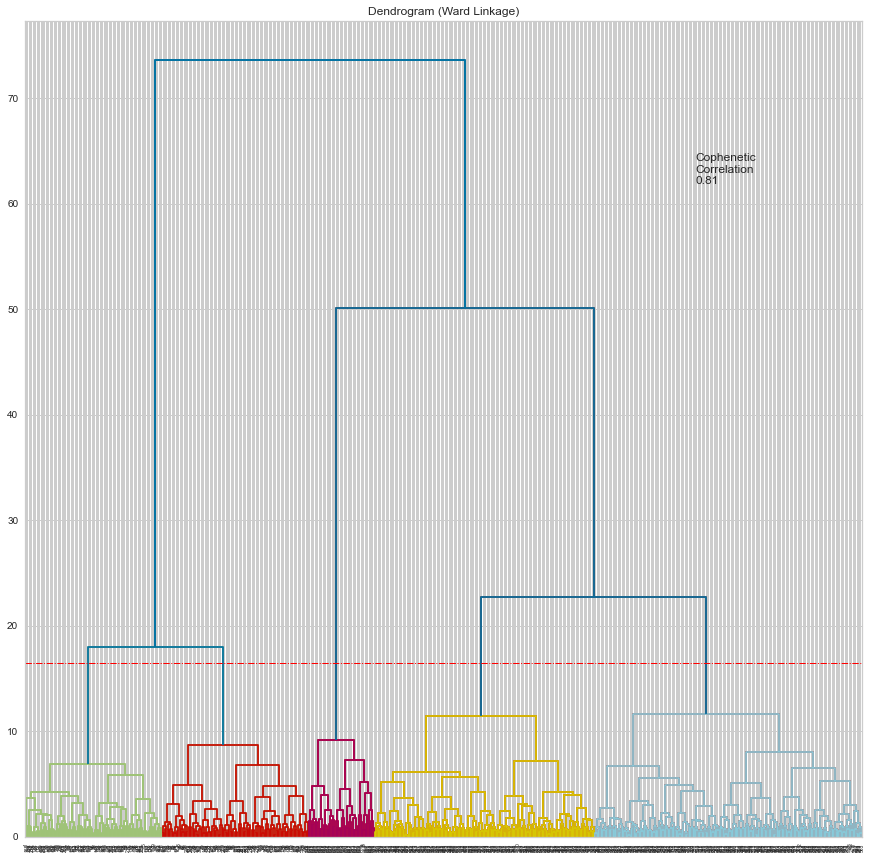

```python
# list of linkage methods
linkage_methods = ["ward"]

# lists to save results of cophenetic correlation calculation
compare_cols = ["Linkage", "Cophenetic Coefficient"]

# to create a subplot image
fig, axs = plt.subplots(len(linkage_methods), 1, figsize=(15, 15))

# We will enumerate through the list of linkage methods above
# For each linkage method, we will plot the dendrogram and calculate the cophenetic correlation
for i, method in enumerate(linkage_methods):
    Z = linkage(subset_scaled_df, metric="euclidean", method=method)

    dendrogram(Z, ax=axs)
    axs.set_title(f"Dendrogram ({method.capitalize()} Linkage)")

    coph_corr, coph_dist = cophenet(Z, pdist(subset_scaled_df))
    axs.annotate(
        f"Cophenetic\nCorrelation\n{coph_corr:0.2f}",
        (0.80, 0.80),
        xycoords="axes fraction",
    )
dendrogram(Z, color_threshold=16.5)
plt.axhline(y=16.5, c="red", lw=1, linestyle="dashdot")
```

It looks like 5 clusters should do it.

```python
HCmodel = AgglomerativeClustering(n_clusters=5, affinity="euclidean", linkage="ward")
HCmodel.fit(subset_scaled_df)
```

```
AgglomerativeClustering(n_clusters=5)
```

```python
subset_scaled_df["HC_Clusters"] = HCmodel.labels_
df["HC_Clusters"] = HCmodel.labels_
```

```python
cluster_profile = df.groupby("HC_Clusters").mean()
```

```python
# let's see the names of the countries in each cluster
for cl in df["HC_Clusters"].unique():
    print(
        "The",
        df[df["HC_Clusters"] == cl]["Customer Key"].nunique(),
        "countries in cluster",
        cl,
        "are:",
    )
    print(df[df["HC_Clusters"] == cl]["Customer Key"].unique())
    print("-" * 100, "\n")
```

```
The 167 countries in cluster 1 are:
[87073 54838 97825 83125 83290 81878 85799 81531 56843 89328 71402 67193
 97109 66504 53207 95925 49771 74544 73952 77026 75775 54906 94666 95610
 85337 67911 92956 77641 78002 91987 87485 81863 92782 47437 64672 62483
 85614 96548 69028 70779 67046 77381 81940 66706 87838 94437 66804 61996
 71681 71862 96186 88807 82376 98126 80347 62807 92522 57459 61994 72431
 85122 96929 78912 68439 62864 77954 88207 78618 75792 97954 90189 55090
 88884 92140 88123 87456 97530 76209 61122 93496 64519 96297 58019 87219
 60851 65747 81166 70707 84351 64774 94595 92489 92933 70101 77613 84360
 67258 65781 62649 74446 76024 75065 95147 76957 61324 77826 61216 83192
 82023 73000 64550 90131 94529 81910 76492 99131 99437 91242 63710 90860
 69868 83585 68040 50706 75417 85645 83545 75398 90999 70376 80942 97850
 79885 59316 83466 81510 88411 96269 87683 58116 67282 84888 75366 96534
 68920 67637 60839 59170 90586 56270 87670 58511 76398 93310 94700 67860
 99473 68862 93381 74083 72339 99284 67415 58276 85234 90191 80623]
```

[output cut: 54 more lines]

The clusters now clearly have much more variability.

```python
# lets display cluster profile
cluster_profile.style.highlight_max(color="lightgreen", axis=0)
```

| HC_Clusters | Customer Key | Avg_Credit_Limit | Total_Credit_Cards | Total_visits_bank | Total_visits_online | Total_calls_made |
| --- | --- | --- | --- | --- | --- | --- |
| 0 | 36065.588235 | 32.088235 | 5.416667 | 3.387255 | 1.009804 | 2.088235 |
| 1 | 78405.476190 | 36.922619 | 5.625000 | 3.559524 | 0.958333 | 1.863095 |
| 2 | 56708.760000 | 141.040000 | 8.740000 | 0.600000 | 10.900000 | 1.080000 |
| 3 | 76506.125000 | 12.232143 | 2.098214 | 0.937500 | 3.482143 | 6.901786 |
| 4 | 33051.000000 | 12.326923 | 2.730769 | 0.980769 | 3.692308 | 7.009615 |

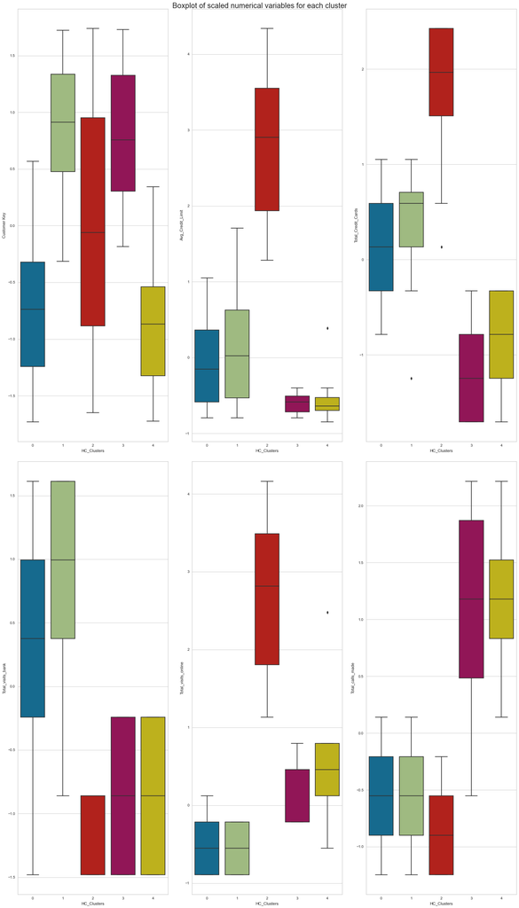

```python
fig, axes = plt.subplots(2, 3, figsize=(20, 35))
fig.suptitle("Boxplot of scaled numerical variables for each cluster", fontsize=20)
counter = 0
for ii in range(2):
    sns.boxplot(
        ax=axes[ii][0],
        y=subset_scaled_df[num_cols[counter]],
        x=subset_scaled_df["HC_Clusters"],
    )
    counter = counter + 1
    sns.boxplot(
        ax=axes[ii][1],
        y=subset_scaled_df[num_cols[counter]],
        x=subset_scaled_df["HC_Clusters"],
    )
    counter = counter + 1
    sns.boxplot(
        ax=axes[ii][2],
        y=subset_scaled_df[num_cols[counter]],
        x=subset_scaled_df["HC_Clusters"],
    )
    counter = counter + 1


fig.tight_layout(pad=2.0)
```

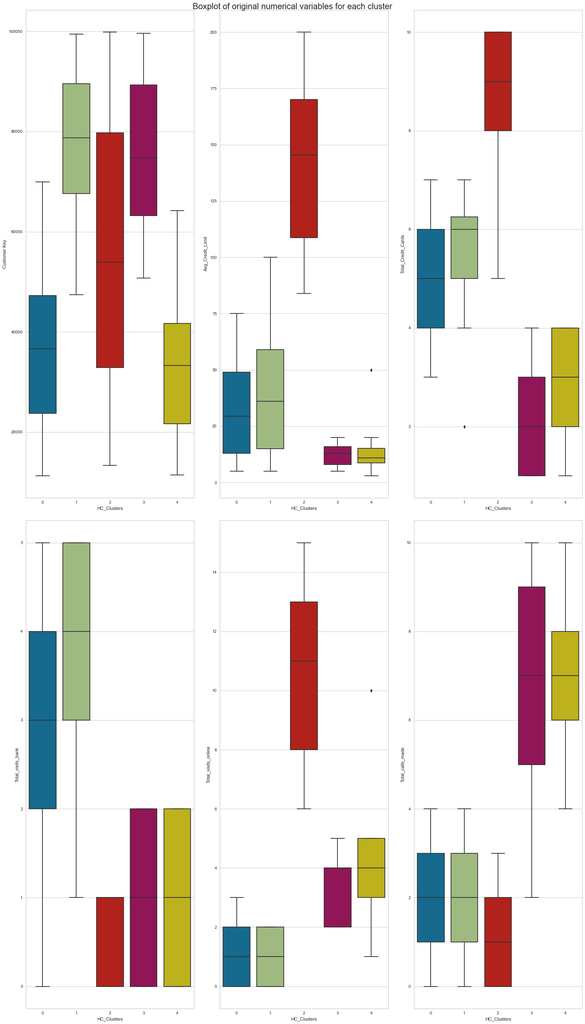

```python
fig, axes = plt.subplots(2, 3, figsize=(20, 35))
fig.suptitle("Boxplot of original numerical variables for each cluster", fontsize=20)
counter = 0
for ii in range(2):
    sns.boxplot(ax=axes[ii][0], y=df[num_cols[counter]], x=df["HC_Clusters"])
    counter = counter + 1
    sns.boxplot(ax=axes[ii][1], y=df[num_cols[counter]], x=df["HC_Clusters"])
    counter = counter + 1
    sns.boxplot(ax=axes[ii][2], y=df[num_cols[counter]], x=df["HC_Clusters"])
    counter = counter + 1


fig.tight_layout(pad=2.0)
```

**Insights**  
All the clusters are fairly important as they all contain numerous customers.

```python
subset_scaled_df = subset_scaled_df.drop("HC_Clusters", axis=1)
```

```
Number of Clusters: 1 	Average Distortion: 2.336819320476793
Number of Clusters: 2 	Average Distortion: 1.8210373670640183
Number of Clusters: 3 	Average Distortion: 1.5007826304409937
Number of Clusters: 4 	Average Distortion: 1.3604679095185308
Number of Clusters: 5 	Average Distortion: 1.2701595704380901
Number of Clusters: 6 	Average Distortion: 1.2181093868027764
Number of Clusters: 7 	Average Distortion: 1.1778890803950723
Number of Clusters: 8 	Average Distortion: 1.1439184098674804
```

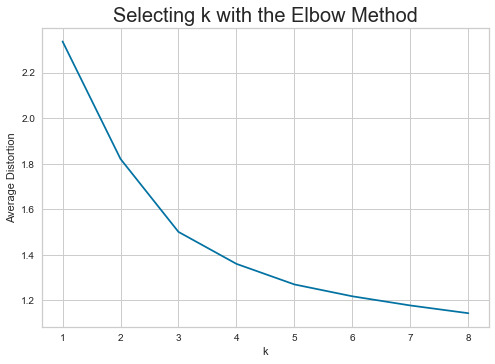

```python
clusters = range(1, 9)
meanDistortions = []

for k in clusters:
    model = KMeans(n_clusters=k)
    model.fit(subset_scaled_df)
    prediction = model.predict(subset_scaled_df)
    distortion = (
        sum(
            np.min(cdist(subset_scaled_df, model.cluster_centers_, "euclidean"), axis=1)
        )
        / subset_scaled_df.shape[0]
    )

    meanDistortions.append(distortion)

    print("Number of Clusters:", k, "\tAverage Distortion:", distortion)

plt.plot(clusters, meanDistortions, "bx-")
plt.xlabel("k")
plt.ylabel("Average Distortion")
plt.title("Selecting k with the Elbow Method", fontsize=20)
```

We will be using either 3 or 4 clusters.

```
For n_clusters = 2, silhouette score is 0.35225786689104377
For n_clusters = 3, silhouette score is 0.44388408338653124
For n_clusters = 4, silhouette score is 0.33549484357161463
For n_clusters = 5, silhouette score is 0.28921561806734314
For n_clusters = 6, silhouette score is 0.25827064222404034
For n_clusters = 7, silhouette score is 0.24173192085865636
For n_clusters = 8, silhouette score is 0.21800077193115946
For n_clusters = 9, silhouette score is 0.20863987394592168
```

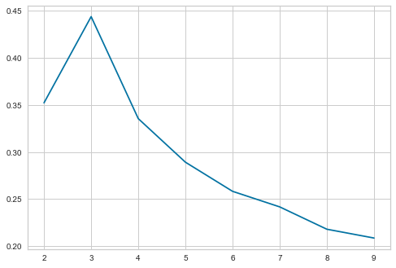

```python
sil_score = []
cluster_list = list(range(2, 10))
for n_clusters in cluster_list:
    clusterer = KMeans(n_clusters=n_clusters)
    preds = clusterer.fit_predict((subset_scaled_df))
    # centers = clusterer.cluster_centers_
    score = silhouette_score(subset_scaled_df, preds)
    sil_score.append(score)
    print("For n_clusters = {}, silhouette score is {}".format(n_clusters, score))

plt.plot(cluster_list, sil_score)
```

Per the silhouette scores it'll have to be 3.

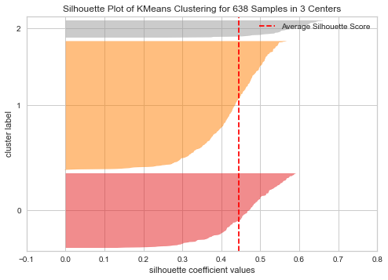

```python
visualizer = SilhouetteVisualizer(KMeans(3, random_state=1))
visualizer.fit(subset_scaled_df)
visualizer.show()
```

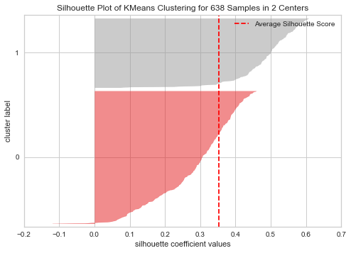

```python
# finding optimal no. of clusters with silhouette coefficients
visualizer = SilhouetteVisualizer(KMeans(2, random_state=1))
visualizer.fit(subset_scaled_df)
visualizer.show()
```

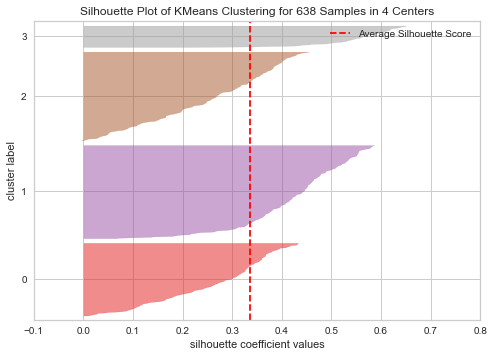

```python
# finding optimal no. of clusters with silhouette coefficients
visualizer = SilhouetteVisualizer(KMeans(4, random_state=1))
visualizer.fit(subset_scaled_df)
visualizer.show()
```

Three Clusters seems to be the right amount.

```python
kmeans = KMeans(n_clusters=3, random_state=0)
kmeans.fit(subset_scaled_df)
```

```
KMeans(n_clusters=3, random_state=0)
```

```python
subset_scaled_df["K_means_segments"] = kmeans.labels_
print(df)
```

[output not shown]

```python
cluster_profile = subset_scaled_df.groupby("K_means_segments").mean()
```

```python
cluster_profile["count_in_each_segment"] = (
    subset_scaled_df.groupby("K_means_segments")["Customer Key"].count().values
)
```

```python
cluster_profile.style.highlight_max(color="lightgreen", axis=0)
```

[output not shown]

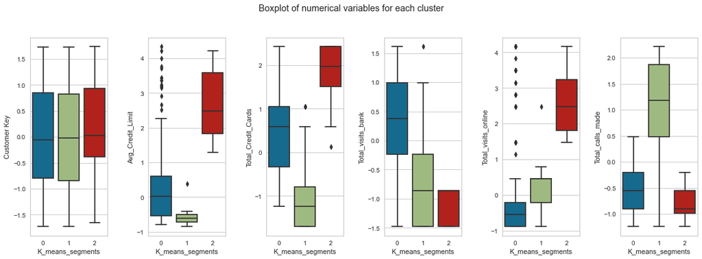

```python
fig, axes = plt.subplots(1, 6, figsize=(16, 6))
fig.suptitle("Boxplot of numerical variables for each cluster")
counter = 0
for ii in range(6):
    sns.boxplot(
        ax=axes[ii], y=subset_scaled_df[num_col[counter]], x=df["K_means_segments"]
    )
    counter = counter + 1
fig.tight_layout(pad=2.0)
```

[figure not shown]

```python
subset_scaled_df.groupby("K_means_segments").mean().plot.bar(figsize=(15, 6))
```

**Insights**